# muHVT : Using mlayerHVT() for Monitoring Entities over Time

Zubin Dowlaty, Shantanu Vaidya

2023-03-03

# 1 Abstract

The muHVT package is a collection of R functions to facilitate building [topology preserving maps](https://link.springer.com/chapter/10.1007/1-84628-118-0_7) for rich multivariate data. Tending towards a big data preponderance, a large number of rows. A collection of R functions for this typical workflow is organized below :

1. **Data Compression**: Vector quantization (VQ), HVQ (hierarchical vector quantization) using means or medians. This step compresses the rows (long data frame) using a compression objective
2. **Data Projection**: Dimension projection of the compressed cells to 1D,2D and 3D with the Sammons Non-linear Algorithm. This step creates topology preserving map coordinates into the desired output dimension
3. **Tessellation**: Create cells required for object visualization using the Voronoi Tessellation method, package includes heatmap plots for hierarchical Voronoi tessellations (HVT). This step enables data insights, visualization, and interaction with the topology preserving map. Useful for semi-supervised tasks
4. **Prediction**: Scoring new data sets and recording their assignment using the map objects from the above steps, in a sequence of maps if required

This package now additionally provides functionality to predict based on a set of maps to monitor entities over time.

The creation of a predictive set involves four steps -

1. **Compress:** Compress the dataset using a percentage compression rate and a quantization threshold using the HVT() function (Map A)
2. **Remove outlier cells:** Manually identify and remove the outlier cells from the dataset using the removeOutliers() function (Map B)
3. **Compress the dataset without outliers:** Again compress the dataset without outlier(s) using n_cells, depth and a quantization threshold using the HVT() function (Map C)
4. **Predict based on a predictive set of maps:** Using the mlayerHVT() function

Let us try to understand the steps with the help of the diagram below.

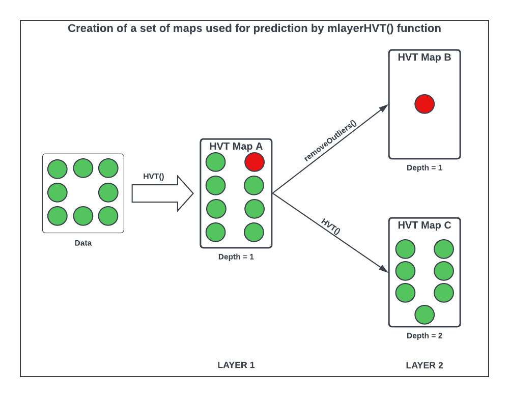

Figure 1: Flow diagram for predicting based on a set of maps using mlayerHVT()

Initially, the raw data is passed, and a highly compressed Map A is constructed using the **`HVT`** function. The output of this function will be hierarchically arranged vector quantized data that is used to identify the outlier cells in the dataset using the number of data points within each cell and the z-scores for each cell.

The identified outlier cell(s) is then passed to the **`removeOutliers`** function along with Map A. This function removes the identified outlier cell(s) from the dataset and stores them in Map B as shown in the diagram. The final output of this function is a list of two items - a newly constructed map (Map B), and a subset of the dataset without outlier cell(s).

The **`plotCells`** function plots the Voronoi tessellations for the compressed map (Map A) and highlights the identified outlier cell(s) in red on the plot. The function requires the identified outlier cell(s) number and the compressed map (Map A) as input in order to plot the tessellations map and highlight those outlier cells on it.

The dataset without outlier(s) gotten as an output from the removeOutliers function is then passed as an argument to the **`HVT`** function with other parameters such as n_cells, quant.error, depth, etc. to construct another map (Map C).

Finally, all the constructed maps are passed to the **`mlayerHVT`** function along with the test dataset on which the function will predict/score for finding which map and what cell each test record gets assigned to.

# 2 Data Understanding

In this notebook, we will use the **`Prices of Personal Computers`** dataset. This dataset contains 6261 observations and 6 features. The dataset observes the price from 1993 to 1995 of 486 personal computers in the US. The variables are price, speed, hd, ram, screen and ads.

Here, we load the data and store into a variables.

```r
set.seed(240)
# Load data from csv files
trainComputers <- read.csv("https://raw.githubusercontent.com/Mu-Sigma/muHVT/dev/vignettes/sample_dataset/trainComputers.csv")
testComputers <- read.csv("https://raw.githubusercontent.com/Mu-Sigma/muHVT/dev/vignettes/sample_dataset/testComputers.csv")
```

Let’s have a look at some of the training data

```r
# Quick peek
Table(head(trainComputers))
```

| price | speed | hd | ram | screen | ads |
| --- | --- | --- | --- | --- | --- |
| 1499 | 25 | 80 | 4 | 14 | 94 |
| 1795 | 33 | 85 | 2 | 14 | 94 |
| 1595 | 25 | 170 | 4 | 15 | 94 |
| 1849 | 25 | 170 | 8 | 14 | 94 |
| 3295 | 33 | 340 | 16 | 14 | 94 |
| 3695 | 66 | 340 | 16 | 14 | 94 |

Now let us check the structure of the training data

```r
str(trainComputers)
```

```
#> 'data.frame':    5008 obs. of  6 variables:
#>  $ price : int  1499 1795 1595 1849 3295 3695 1720 1995 2225 2575 ...
#>  $ speed : int  25 33 25 25 33 66 25 50 50 50 ...
#>  $ hd    : int  80 85 170 170 340 340 170 85 210 210 ...
#>  $ ram   : int  4 2 4 8 16 16 4 2 8 4 ...
#>  $ screen: int  14 14 15 14 14 14 14 14 14 15 ...
#>  $ ads   : int  94 94 94 94 94 94 94 94 94 94 ...
```

Let’s get a summary of the training data

```r
summary(trainComputers)
```

```
#>      price          speed              hd              ram
#>  Min.   : 949   Min.   : 25.00   Min.   :  80.0   Min.   : 2.000
#>  1st Qu.:1824   1st Qu.: 33.00   1st Qu.: 212.0   1st Qu.: 4.000
#>  Median :2195   Median : 50.00   Median : 340.0   Median : 8.000
#>  Mean   :2271   Mean   : 48.21   Mean   : 356.1   Mean   : 7.677
#>  3rd Qu.:2644   3rd Qu.: 66.00   3rd Qu.: 450.0   3rd Qu.: 8.000
#>  Max.   :5399   Max.   :100.00   Max.   :2100.0   Max.   :32.000
#>      screen           ads
#>  Min.   :14.00   Min.   : 94.0
#>  1st Qu.:14.00   1st Qu.:216.0
#>  Median :14.00   Median :259.0
#>  Mean   :14.53   Mean   :243.7
#>  3rd Qu.:15.00   3rd Qu.:283.0
#>  Max.   :17.00   Max.   :339.0
```

# 3 Map A : Compress using vector quantization

This package can perform vector quantization using the following algorithms -

- Hierarchical Vector Quantization using k−means
- Hierarchical Vector Quantization using k−medoids

For more information on vector quantization, refer the following [link](https://htmlpreview.github.io/?https://raw.githubusercontent.com/Mu-Sigma/muHVT/dev/vignettes/muHVT_vignette.html#compress-vector-quantization).

Let us try to understand the HVT function -

```r
HVT(
  dataset,
  min_compression_perc,
  n_cells,
  depth,
  quant.err,
  distance_metric = c("L1_Norm", "L2_Norm"),
  error_metric = c("mean", "max"),
  quant_method = c("kmeans", "kmedoids"),
  normalize = TRUE,
  diagnose = FALSE,
  hvt_validation = FALSE,
  train_validation_split_ratio = 0.8
)
```

First, we will construct Map A by performing Hierarchical Vector Quantization by setting the parameter min_compression_perc to 70% and quantization error threshold to 0.2. The compressed map is always constructed at depth = 1.

```r
hvt_mapA <- list()

hvt_mapA <-muHVT::HVT(trainComputers,
                min_compression_perc = 70,
                quant.err = 0.2,
                distance_metric = "L1_Norm",
                error_metric = "max",
                quant_method = "kmeans",
                normalize = TRUE
)
```

[1] “For the given dataset 70% compression rate is achieved at n_cells : 318”

Now, let’s check the compression summary for HVT Map A. The table below shows no of cells, no of cells having quantization error below threshold and percentage of cells having quantization error below threshold for each level.

```r
mapA_compression_summary <- hvt_mapA[[3]]$compression_summary %>%  dplyr::mutate_if(is.numeric, funs(round(.,4)))
DT::datatable(mapA_compression_summary, class = 'cell-border stripe', options = list(scrollX = TRUE))
```

|  | segmentLevel | noOfCells | noOfCellsBelowQuantizationError | percentOfCellsBelowQuantizationErrorThreshold | parameters |
| --- | --- | --- | --- | --- | --- |
| 1 | 1 | 318 | 224 | 0.7044 | n_cells: 318 quant.err: 0.2 distance_metric: L1_Norm error_metric: max quant_method: kmeans |

As per the manual, **`hvt_mapA[[3]]`** gives us detailed information about the hierarchical vector quantized data. **`hvt_mapA[[3]][['summary']]`** gives a nice tabular data containing no of points, Quantization Error and the codebook.

Now let us understand what each column in the above table means:

- **`Segment.Level`** - Level of the cell. In this case, we have performed Vector Quantization for depth 1. Hence Segment Level is 1
- **`Segment.Parent`** - Parent segment of the cell
- **`Segment.Child (Cell.Number)`** - The children of a particular cell. In this case, it is the total number of cells at which we achieved the defined compression percentage
- **`n`** - No of points in each cell
- **`Cell.ID`** - Cell_ID’s are generated for the multivariate data using 1-D Sammon’s Projection algorithm
- **`Quant.Error`** - Quantization Error for each cell

All the columns after this will contain centroids for each cell. They can also be called a codebook, which represents a collection of all centroids or codewords.

```r
cell_mapping_df <- arrange(hvt_mapA[[3]]$summary, n) %>% mutate_if(is.numeric, round, digits = 4)
DT::datatable(cell_mapping_df, filter = 'top', options = list(pageLength = 10, scrollX = TRUE), class = 'cell-border stripe')
```

|  | Segment.Level | Segment.Parent | Segment.Child | n | Cell.ID | Quant.Error | price | speed | hd | ram | screen | ads |
| --- | --- | --- | --- | --- | --- | --- | --- | --- | --- | --- | --- | --- |
| 1 | 1 | 1 | 53 | 2 | 313 | 0 | 2.8957 | 0.9159 | 0.323 | 4.7461 | 0.549 | 0.4996 |
| 2 | 1 | 1 | 137 | 3 | 25 | 0.0878 | -1.9415 | -0.7834 | -0.5683 | -0.9777 | -0.615 | 0.0689 |
| 3 | 1 | 1 | 198 | 3 | 198 | 0.177 | -0.3041 | 2.6667 | -0.4763 | -0.7176 | 0.549 | 0.5156 |
| 4 | 1 | 1 | 271 | 3 | 318 | 0.0355 | 5.2569 | 0.9159 | 4.0148 | 4.7461 | 2.8768 | 0.4571 |
| 5 | 1 | 1 | 305 | 3 | 180 | 0.0505 | 1.2062 | -0.7834 | -0.0767 | 0.063 | -0.615 | 0.4996 |
| 6 | 1 | 1 | 10 | 4 | 8 | 0.0482 | -2.0872 | -0.7834 | -1.2066 | -1.1078 | -0.615 | 0.7589 |
| 7 | 1 | 1 | 150 | 4 | 304 | 0.1573 | 2.694 | 2.6667 | 1.7692 | 0.063 | 0.549 | -0.5374 |
| 8 | 1 | 1 | 161 | 4 | 245 | 0.1592 | 1.8538 | -0.1269 | 0.4467 | 0.063 | 0.549 | 0.2563 |
| 9 | 1 | 1 | 260 | 4 | 126 | 0.0926 | 0.0303 | -0.3457 | -0.0767 | -0.7176 | -0.615 | 1.5207 |
| 10 | 1 | 1 | 306 | 4 | 9 | 0.0856 | -2.0578 | -0.7834 | -1.2066 | -1.1078 | -0.615 | -0.1904 |

[output cut: 308 more lines]

Let’s have look at the function `hvtHmap` which we will use to overlay a variable as heatmap.

```r
hvtHmap(hvt.results, dataset, child.level, hmap.cols, color.vec ,line.width, palette.color = 6)
```

- **`hvt.results`** - A list of hvt.results obtained from the HVT function
- **`dataset`** - A dataframe containing the variables to overlay as a heatmap. The user can pass an external dataset or the dataset that was used to perform hierarchical vector quantization. The dataset should have the same number of points as the dataset used to perform hierarchical Vector Quantization in the HVT function
- **`child.level`** - A number indicating the level for which the heat map is to be plotted
- **`hmap.cols`** - The column number of column name from the dataset indicating the variables for which the heat map is to be plotted. To plot the quantization error as heatmap, pass `'quant_error'`. Similarly to plot the no of points in each cell as heatmap, pass `'no_of_points'` as a parameter
- **`color.vec`** - A color vector such that length(color.vec) = child.level (default = NULL)
- **`line.width`** - A line width vector such that length(line.width) = child.level (default = NULL)
- **`palette.color`** - A number indicating the heat map color palette. 1 - rainbow, 2 - heat.colors, 3 - terrain.colors, 4 - topo.colors, 5 - cm.colors, 6 - BlCyGrYlRd (Blue,Cyan,Green,Yellow,Red) color (default = 6)
- **`show.points`** - A boolean indicating whether the centroids should be plotted on the tessellations (default = FALSE)

Now let’s plot all the features for each cell at level one as a heatmap.

```r
hmap <- list()
col_list <- colnames(trainComputers)
hmap <- lapply(1:length(col_list), function(x){
  hvtHmap(
  hvt_mapA,
  scores,
  child.level = 1,
  hmap.cols = col_list[[x]],
  line.width = c(0.2),
  color.vec = c("#141B41"),
  palette.color = 6,
  centroid.size = 1.0,
  show.points = T,
  quant.error.hmap = 0.2,
  n_cells.hmap = 15,
) #%>% ggplotly() # for plotly
})
```

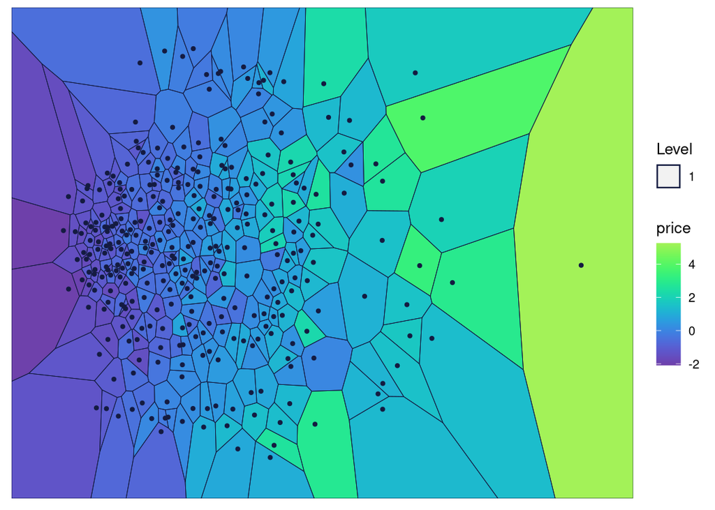

```r
grid.arrange(hmap[[1]], nrow = 1, ncol=1)
```

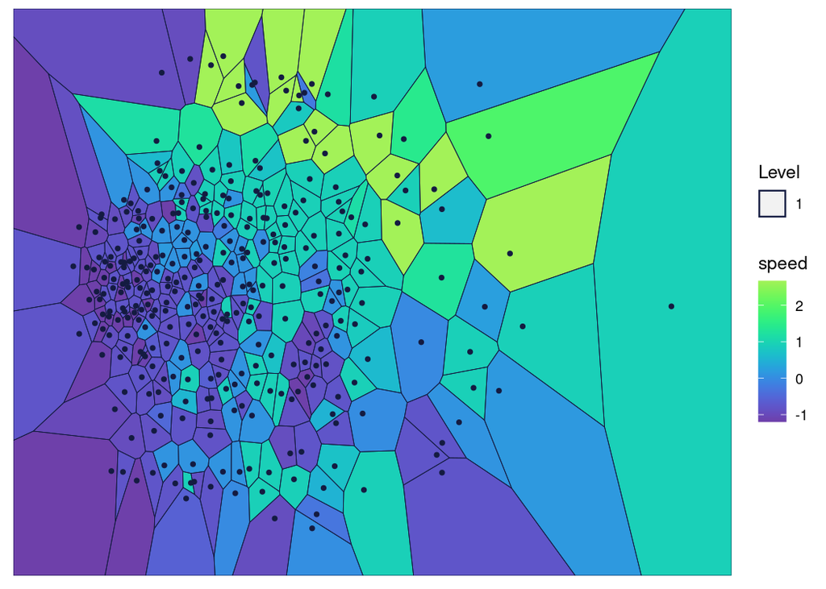

```r
grid.arrange(hmap[[2]], nrow = 1, ncol=1)
```

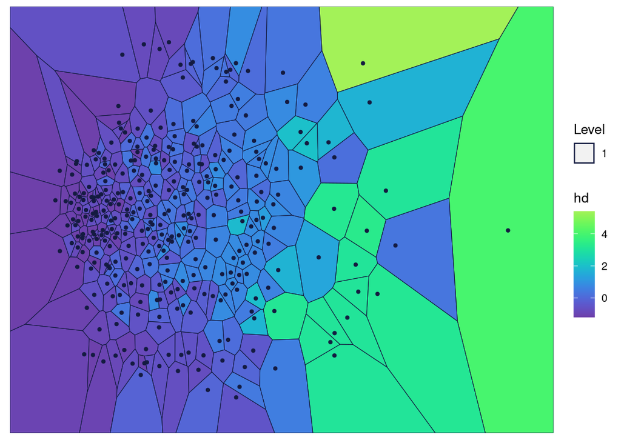

```r
grid.arrange(hmap[[3]], nrow = 1, ncol=1)
```

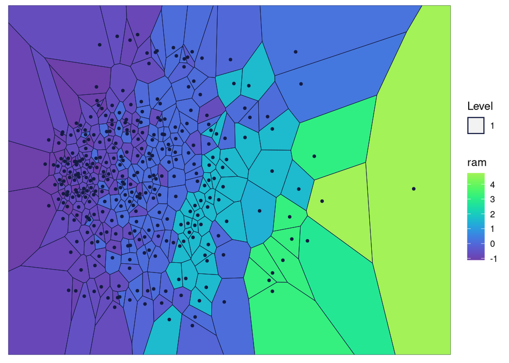

```r
grid.arrange(hmap[[4]], nrow = 1, ncol=1)
```

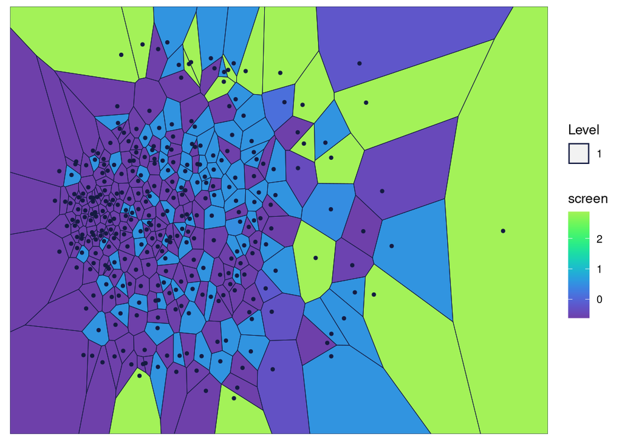

```r
grid.arrange(hmap[[5]], nrow = 1, ncol=1)
```

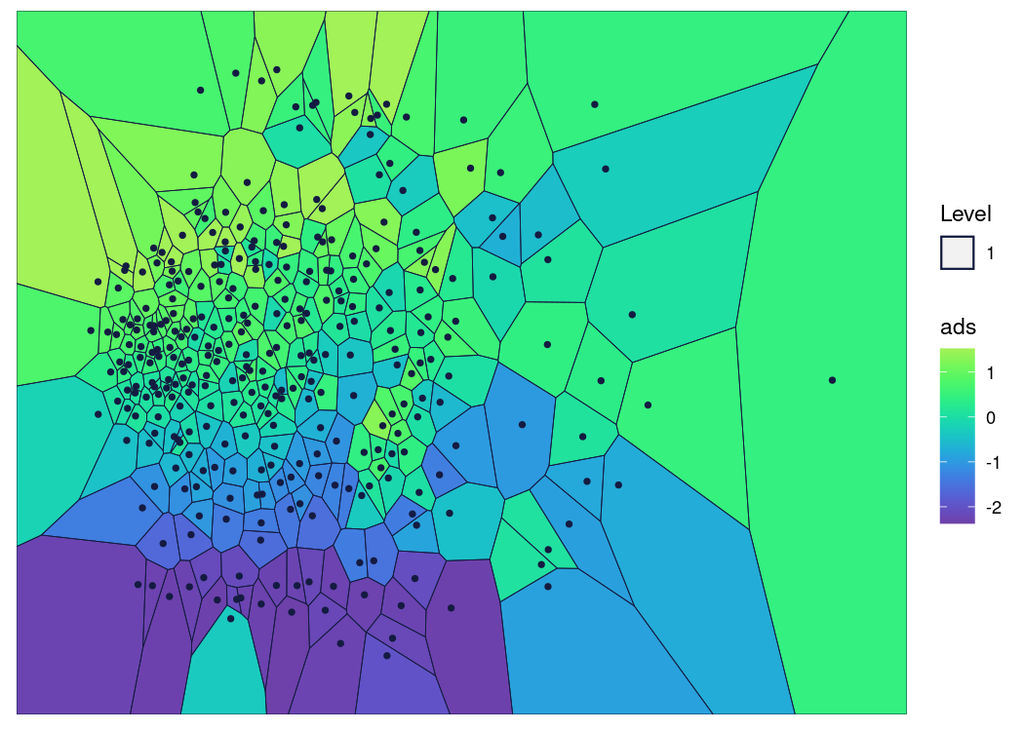

```r
grid.arrange(hmap[[6]], nrow = 1, ncol=1)
```

# 4 Map B : Identify and remove the outlier cells

The removeOutliers function removes the identified outlier cell(s) from the dataset and stores them in Map B.

```r
identified_outlier_cells <- c(10, 53, 198)
output_list <- removeOutliers(identified_outlier_cells, hvt_mapA)
```

[1] “The following cell(s) have been removed as outliers from the dataset: 10 53 198”

```r
hvt_mapB <- output_list[[1]]
dataset_without_outliers <- output_list[[2]]
```

**Note** - In the HVT Map B, the total number of cells would be equal to the total number of outlier cell(s) removed from the HVT Map A. Let’s say, as in the above case where three cells (10th, 53rd, and 198th) are identified as the outlier are removed. Then the 10th cell would be the first cell in the HVT Map B, 53rd as the second cell, and 198th as the third cell.

Let’s have a look at the removed outlier rows data

|  | Cell.ID | Cell.Number | price | speed | hd | ram | screen | ads |
| --- | --- | --- | --- | --- | --- | --- | --- | --- |
| 1 | 8 | 10 | -2.0536 | -0.7834 | -1.3136 | -1.1078 | -0.615 | 0.8666 |
| 2 | 8 | 10 | -2.1376 | -0.7834 | -1.3136 | -1.1078 | -0.615 | 0.6273 |
| 3 | 8 | 10 | -1.9359 | -0.7834 | -1.0995 | -1.1078 | -0.615 | 0.7708 |
| 4 | 8 | 10 | -2.2216 | -0.7834 | -1.0995 | -1.1078 | -0.615 | 0.7708 |
| 5 | 313 | 53 | 2.8957 | 0.9159 | 0.323 | 4.7461 | 0.549 | 0.4996 |
| 6 | 313 | 53 | 2.8957 | 0.9159 | 0.323 | 4.7461 | 0.549 | 0.4996 |
| 7 | 198 | 198 | -0.4722 | 2.6667 | -0.0767 | -0.7176 | 0.549 | 1.0101 |
| 8 | 198 | 198 | -0.136 | 2.6667 | -0.6761 | -0.7176 | 0.549 | 0.4677 |
| 9 | 198 | 198 | -0.3041 | 2.6667 | -0.6761 | -0.7176 | 0.549 | 0.0689 |

## 4.1 Voronoi tessellation to highlight outlier cell in the map

The plotCells function is used to plot the Voronoi tessellation using the compressed HVT map (Map A) and highlights the identified outlier cell(s) in red on the map.

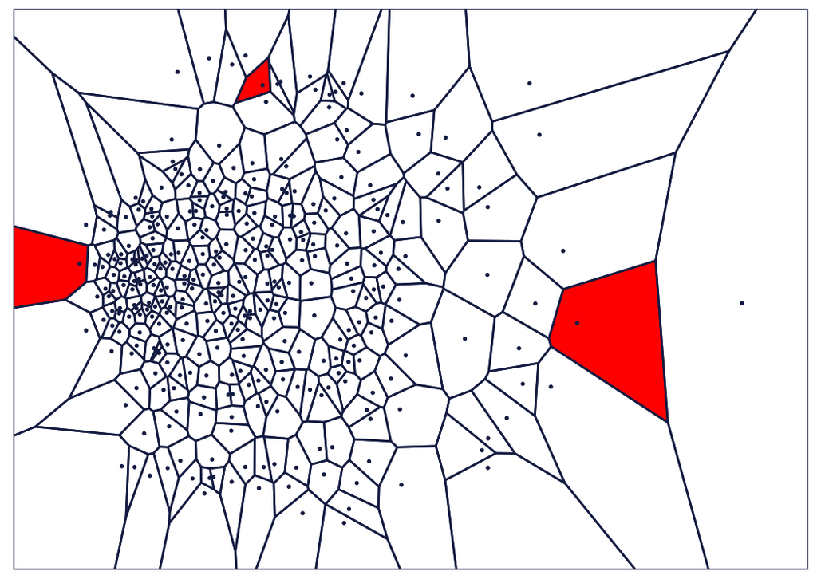

Figure 3: The Voronoi Tessellation constructed using the compressed HVT map (Map A) with the outlier cell(s) highlighted in red

```r
plotCells(identified_outlier_cells, hvt_mapA)
```

# 5 Map C : Construct a map on the dataset without outlier(s)

Construct another hierarchical Voronoi tessellation (Map C) on the dataset without outlier(s) using the HVT function.

Pass the following as inputs to the HVT function - the ‘n_cells’ parameter which determines the number of cells at each depth, ‘depth’ indicates the number of levels, and ‘quant.err’ acts as a threshold and determines the number of levels in the hierarchy.

```r
set.seed(240)
hvt_mapC <- list()

mapA_scale_summary = hvt_mapA[[3]]$scale_summary
hvt_mapC <- HVT(dataset_without_outliers,
                    n_cells = 15,
                    depth = 2,
                    quant.err = 0.2,
                    distance_metric = "L1_Norm",
                    error_metric = "max",
                    quant_method = "kmeans",
                    projection.scale = 10,
                    normalize = FALSE,
                    scale_summary = mapA_scale_summary)
```

Now let’s check the compression summary for HVT Map C. The table below shows no of cells, no of cells having quantization error below threshold and percentage of cells having quantization error below threshold for each level.

```r
mapC_compression_summary <- hvt_mapC[[3]]$compression_summary %>%  dplyr::mutate_if(is.numeric, funs(round(.,4)))
DT::datatable(mapC_compression_summary, class = 'cell-border stripe', options = list(scrollX = TRUE))
```

|  | segmentLevel | noOfCells | noOfCellsBelowQuantizationError | percentOfCellsBelowQuantizationErrorThreshold | parameters |
| --- | --- | --- | --- | --- | --- |
| 1 | 1 | 15 | 0 | 0 | n_cells: 15 quant.err: 0.2 distance_metric: L1_Norm error_metric: max quant_method: kmeans |
| 2 | 2 | 225 | 91 | 0.4044 | n_cells: 15 quant.err: 0.2 distance_metric: L1_Norm error_metric: max quant_method: kmeans |

**`hvt_mapC[[3]]`** gives us detailed information about the hierarchical vector quantized data. **`hvt_mapC[[3]][['summary']]`** gives a nice tabular data containing no of points, Quantization Error and the codebook.

|  | Segment.Level | Segment.Parent | Segment.Child | n | Cell.ID | Quant.Error | price | speed | hd | ram | screen | ads |
| --- | --- | --- | --- | --- | --- | --- | --- | --- | --- | --- | --- | --- |
| 1 | 2 | 12 | 14 | 27 | 1 | 0.2304 | -1.2158 | -1.1954 | -1.0026 | -0.7898 | -0.4856 | -2.3094 |
| 2 | 2 | 10 | 4 | 10 | 2 | 0.1739 | 0.7278 | -0.7834 | -0.5429 | -0.0931 | 2.8768 | -2.1774 |
| 3 | 2 | 12 | 1 | 31 | 3 | 0.4417 | -1.0098 | -0.5857 | -1.1578 | -0.9693 | -0.5399 | -2.1862 |
| 4 | 2 | 2 | 12 | 46 | 4 | 0.4 | -0.5738 | -0.9177 | -0.5462 | -0.743 | 2.8768 | 0.4951 |
| 5 | 2 | 3 | 5 | 4 | 5 | 0.0352 | -0.2566 | 2.6667 | -1.1852 | -1.1078 | -0.615 | 1.5207 |
| 6 | 2 | 3 | 3 | 2 | 6 | 0.0425 | -0.3041 | 2.6667 | -1.1852 | -1.1078 | 0.549 | 1.2654 |
| 7 | 2 | 11 | 7 | 11 | 7 | 0.1298 | -1.2726 | -0.9707 | -1.0433 | -0.8949 | -0.615 | -1.6701 |
| 8 | 2 | 2 | 8 | 15 | 8 | 0.2146 | -1.4165 | -1.0306 | -0.9711 | -0.8737 | 0.549 | 1.2133 |
| 9 | 2 | 11 | 13 | 16 | 9 | 0.152 | -1.3099 | -1.0409 | -1.1078 | -0.8639 | -0.615 | -1.0798 |
| 10 | 2 | 4 | 5 | 40 | 10 | 0.2435 | -1.2735 | -0.9276 | -0.8388 | -0.7956 | -0.615 | 1.5207 |

[output cut: 230 more lines]

```r
hvtHmap(
  hvt_mapC,
  trainComputers,
  child.level = 2,
  hmap.cols = "price",
  line.width = c(0.6, 0.4),
  color.vec = c("#141B41", "#0582CA"),
  palette.color = 6,
  centroid.size = 1.0,
  show.points = T,
  quant.error.hmap = 0.2,
  n_cells.hmap = 15
)
```

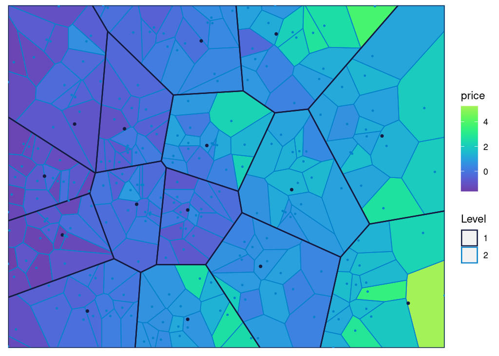

Figure 4: The Voronoi Tessellation with the heat map overlaid for variable ’price’ in the ’computers’ dataset